# Exercise 2_2: Basic Raster Operations

Advanced Geospatial Data Processing for Social Scientists

Author

Dennis Abel & Stefan Jünger

In the next three exercises, we’ll dive into the world of raster data. You’ll practice importing different raster formats, explore the properties of spatial layers, and even create a new raster layer by combining datasets.

Along the way, you might encounter a few common challenges, like dealing with different coordinate systems. These are great opportunities to sharpen your spatial data skills!

Let’s jump in!

### Exercises

**🏋 Exercise 1**

In this exercise, you’ll import a raster `.tif` file from the `./data/z22` folder. Once loaded, take a moment to explore the raster’s dimensions, resolution, and other key properties. Feel free to visualize it to get an initial sense of its content!

**💡 Tip**

You can use the `terra` package to load raster files. With the `terra::rast()` function, you’ll be able to load your `.tif` file and start working with it.

**🏋 Exercise 2**

In this exercise, you’ll import a NetCDF file (`.nc`) from the `./data/z22` folder. Once you’ve successfully loaded it, check out the dimensions and variables within the file. This is a great chance to get familiar with different raster data file formats!

**💡 Tip**

To work with `.nc` files, you can also use the `terra` package. The `terra::rast()` function works for NetCDF files, just like for raster TIF files.

**🏋 Exercise 3**

Now it’s time to get creative! 🎨 You’ve already imported both a TIF file and a NetCDF file. In this exercise, combine these two datasets to create a new raster layer. You can experiment by performing basic operations like adding, multiplying, or averaging the values from the two layers.

**💡 Tip**

However, beware: Since the CRS of the two datasets might not match, you could encounter a warning. Take a moment to investigate and correct it!

- Check the CRS of both datasets with `terra::crs()`.
- If necessary, use `terra::project()` to align the CRS of both layers.
- Once aligned, you can perform mathematical operations like +, -, *, or / on the two layers.

### Solutions

**✅ Solution 1**

```r
library(terra)

# Load the raster data
age_65_tif <- terra::rast("./data/z22/age_from_65.tif")

# Explore the raster
print(age_65_tif)                 # Check basic info
dim(age_65_tif)                   # Check dimensions
terra::res(age_65_tif)            # Resolution

# Optional: visualize it
plot(age_65_tif)
```

```
terra 1.8.42
```

```
class       : SpatRaster
dimensions  : 868, 652, 1  (nrow, ncol, nlyr)
resolution  : 1000.467, 1000.467  (x, y)
extent      : 274144.4, 926449.1, 5236495, 6104901  (xmin, xmax, ymin, ymax)
coord. ref. : ETRS89 / UTM zone 32N (EPSG:25832)
source      : age_from_65.tif
name        :  cat_0
min value   :   0.63
max value   : 100.00
```

```
[1] 868 652   1
```

```
[1] 1000.467 1000.467
```

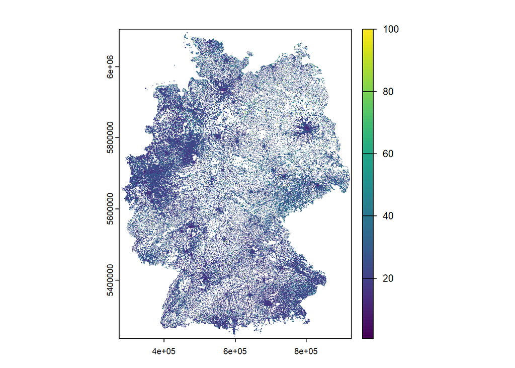

**✅ Solution 2**

```r
# Load the NetCDF file
population_nc <- terra::rast("./data/z22/population.nc")

# Explore the NetCDF file
print(population_nc)             # Check basic info
dim(population_nc)               # View dimensions
names(population_nc)             # Check variable names

# Optional: visualize one of the variables
plot(population_nc[[1]])         # Plot the first variable
```

```
class       : SpatRaster
dimensions  : 859, 641, 1  (nrow, ncol, nlyr)
resolution  : 1000, 1000  (x, y)
extent      : 4031050, 4672050, 2689050, 3548050  (xmin, xmax, ymin, ymax)
coord. ref. : ETRS89-extended / LAEA Europe (EPSG:3035)
source      : population.nc
varname     : cat_0
name        : cat_0
```

```
[1] 859 641   1
```

```
[1] "cat_0"
```

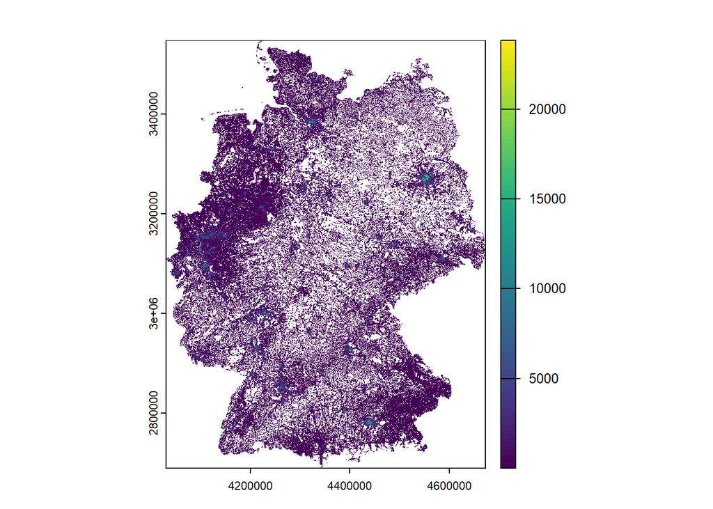

**✅ Solution 3**

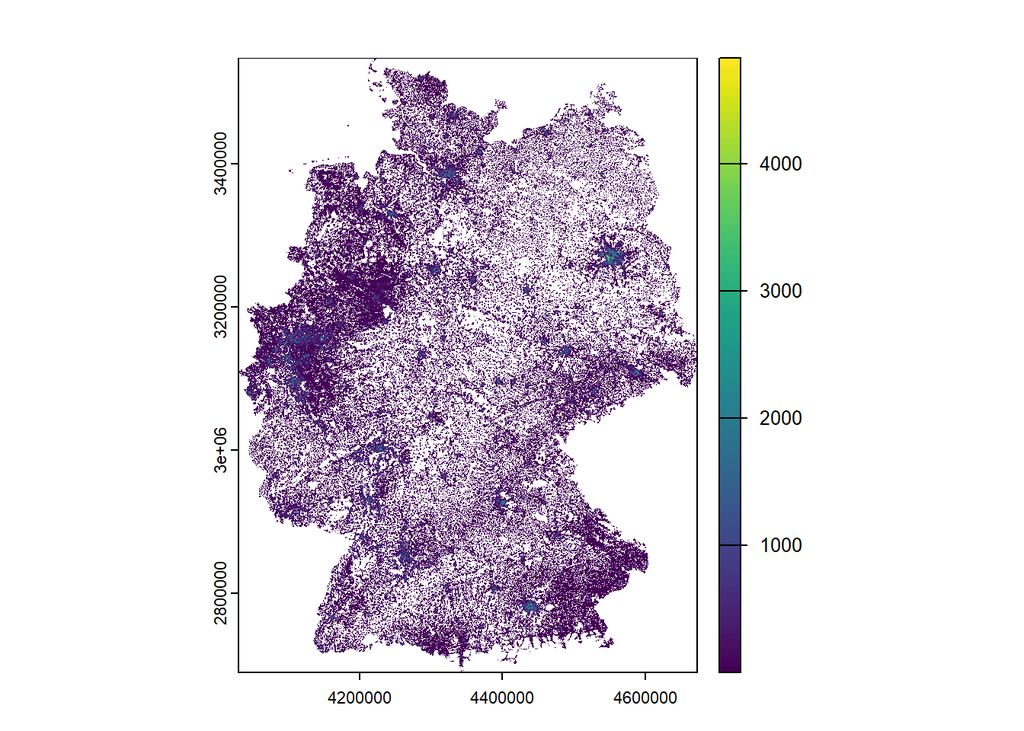

```r
# Check the CRS of both datasets
crs_age_65_tif <- terra::crs(age_65_tif)
crs_population_nc <- terra::crs(population_nc)

# If CRS don't match, align them
if (crs_age_65_tif != crs_population_nc) {
  age_65_tif <- terra::project(age_65_tif, population_nc)
}

# Combine the layers (example: calculate number of people >= 65 years)
old_peeps <- population_nc * (age_65_tif / 100)

# Explore the new raster layer
plot(old_peeps)
```